# Homework 2

Evan Woelk Balzer

15/01/2020

library(tidyverse)

#Question 1# #1a H0:There is no difference in catch tonnage between 2009 and 2010 in the Gulf of Mexico fishery. HA:The 2010 Gulf of Mexico fishery catch tonnage is significantly lower than the 2009 catch tonnage.

#1b

```r
library(ggplot2)
library(tidyverse)
sc <- read_csv("shrimp_catch.csv")
sc
```

```
## # A tibble: 14 x 3
##    `Village Code` `Two thousand nine` `Two thousand ten`
##    <chr>                        <dbl>              <dbl>
##  1 A                            91900              82900
##  2 B                            95200              86700
##  3 C                            61900              46900
##  4 D                            73600              41300
##  5 E                           114300              91600
##  6 F                           117000             100400
##  7 G                           129500             128400
##  8 H                            74200              55900
##  9 I                           112700             101700
## 10 J                           152100             139100
## 11 K                            90700              79300
## 12 L                            89400              76100
## 13 M                           127500             114100
## 14 N                           142200             139800
```

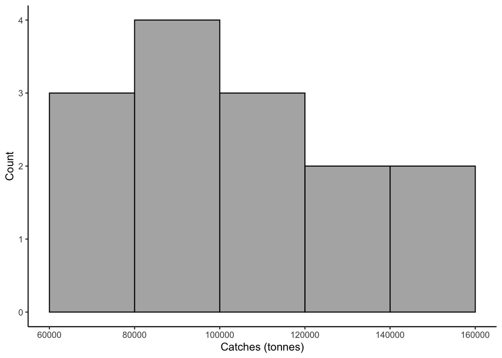

```r
a<- ggplot(sc, aes(`Two thousand nine`))
brx <- pretty(range(sc$`Two thousand nine`), n = nclass.Sturges(sc$`Two thousand nine`),min.n = 1)
NINE <- a+geom_histogram(breaks = brx, alpha = 0.5, color = "black")+labs(x = "Catches (tonnes)", y = "Count")+theme_classic()
NINE
```

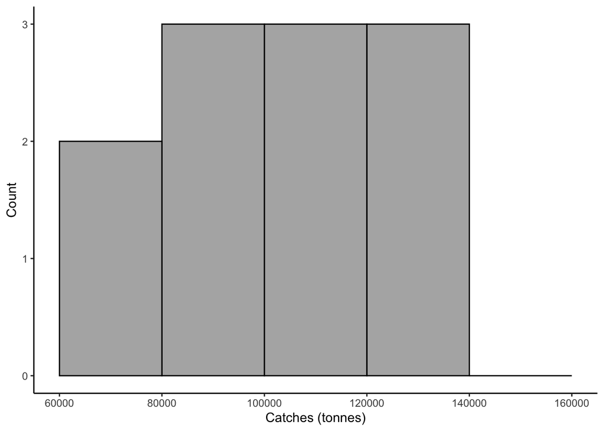

```r
b<- ggplot(sc, aes(`Two thousand ten`))
breax <- pretty(range(sc$`Two thousand ten`), n = nclass.Sturges(sc$`Two thousand ten`),min.n = 1)
TEN <- b+geom_histogram(breaks = brx, alpha = 0.5, color = "black")+labs(x = "Catches (tonnes)", y = "Count")+theme_classic()
TEN
```

c) In this example, the catch data for both years has been measured at the same villages. Accordingly, the data can considered paired, and the appropriate test is the paired t-test. Because we are interested in whether a change has happened, a two-sided test is appropriate. #1d

```r
#getting a vector of catch data#
nin <- sc$`Two thousand nine`
nin
```

```
##  [1]  91900  95200  61900  73600 114300 117000 129500  74200 112700 152100
## [11]  90700  89400 127500 142200
```

```r
tin <- sc$`Two thousand ten`
tin
```

```
##  [1]  82900  86700  46900  41300  91600 100400 128400  55900 101700 139100
## [11]  79300  76100 114100 139800
```

```r
PairedTCatches <- t.test(nin, tin, paired = TRUE)
PairedTCatches
```

```
##
##  Paired t-test
##
## data:  nin and tin
## t = 6.3808, df = 13, p-value = 2.415e-05
## alternative hypothesis: true difference in means is not equal to 0
## 95 percent confidence interval:
##   8882.005 17975.138
## sample estimates:
## mean of the differences
##                13428.57
```

#1e

```r
critshrimp <- qt(0.975, 13)
critshrimp
```

```
## [1] 2.160369
```

The critical value is 2.160369 and the observed t-value is 6.3808.

#1f Since tobs > tcrit, we reject the null hypothesis. We have evidence that catch tonnage in the Gulf of Mexico fishery has changed between 2009 and 2010.

#2a H0: The mean phosphorous level in Lake Erie is not different than 15μg/L HA: The mean phosphorous level in Lake Eerie is greater than 15μg/L

#2b

```r
EeriePhos <- read_csv("EeriePhos.csv")
```

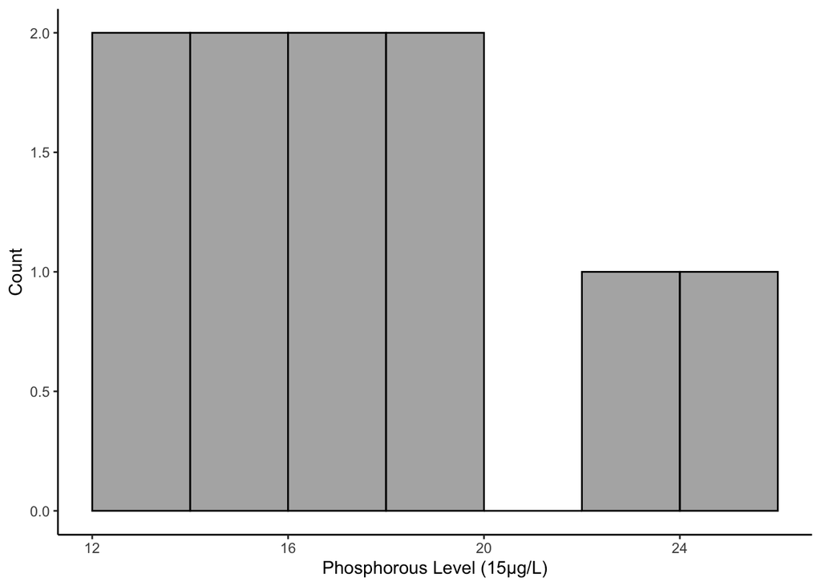

```r
EP <- EeriePhos[1:10,1:2]
c<- ggplot(EP, aes(EP$Phosphorous))
epbrx <- pretty(range(EP$Phosphorous), n = nclass.Sturges(EP$Phosphorous),min.n = 1)
ephist <- c+geom_histogram(breaks = epbrx, alpha = 0.5, color = "black")+labs(x = "Phosphorous Level (15μg/L)", y = "Count")+theme_classic()
ephist
```

#2c We only have data from one set of observations and wish to compare an observed mean to a theoretical one.These conditions meet the criteria for a one-sample t-test. Since we want to know whether the mean is higher than the theoretical mean and have evidence to support that prediction, the test should also be one-sided.